# Laboratorio 1 - Análisis exploratorio, PCA y Apriori

Alexa Bravo, Josué Sagastume

25/7/2021

```
## Package 'mclust' version 5.4.7
```

### 1. Datos

```r
train <- read.csv("./data/train.csv")
```

### 1. Análisis exploratorio

```r
summary(train)
```

```
##        Id           MSSubClass      MSZoning          LotFrontage
##  Min.   :   1.0   Min.   : 20.0   Length:1460        Min.   : 21.00
##  1st Qu.: 365.8   1st Qu.: 20.0   Class :character   1st Qu.: 59.00
##  Median : 730.5   Median : 50.0   Mode  :character   Median : 69.00
##  Mean   : 730.5   Mean   : 56.9                      Mean   : 70.05
##  3rd Qu.:1095.2   3rd Qu.: 70.0                      3rd Qu.: 80.00
##  Max.   :1460.0   Max.   :190.0                      Max.   :313.00
##                                                      NA's   :259
##     LotArea          Street             Alley             LotShape
##  Min.   :  1300   Length:1460        Length:1460        Length:1460
##  1st Qu.:  7554   Class :character   Class :character   Class :character
##  Median :  9478   Mode  :character   Mode  :character   Mode  :character
##  Mean   : 10517
##  3rd Qu.: 11602
##  Max.   :215245
##
##  LandContour         Utilities          LotConfig          LandSlope
##  Length:1460        Length:1460        Length:1460        Length:1460
##  Class :character   Class :character   Class :character   Class :character
##  Mode  :character   Mode  :character   Mode  :character   Mode  :character
##
##
##
##
##  Neighborhood        Condition1         Condition2          BldgType
##  Length:1460        Length:1460        Length:1460        Length:1460
##  Class :character   Class :character   Class :character   Class :character
##  Mode  :character   Mode  :character   Mode  :character   Mode  :character
##
##
##
##
##   HouseStyle         OverallQual      OverallCond      YearBuilt
##  Length:1460        Min.   : 1.000   Min.   :1.000   Min.   :1872
##  Class :character   1st Qu.: 5.000   1st Qu.:5.000   1st Qu.:1954
##  Mode  :character   Median : 6.000   Median :5.000   Median :1973
##                     Mean   : 6.099   Mean   :5.575   Mean   :1971
##                     3rd Qu.: 7.000   3rd Qu.:6.000   3rd Qu.:2000
##                     Max.   :10.000   Max.   :9.000   Max.   :2010
##
```

[output cut: 113 more lines]

```
##  Min.   : 1.000   Min.   :2006   Length:1460        Length:1460
##  1st Qu.: 5.000   1st Qu.:2007   Class :character   Class :character
##  Median : 6.000   Median :2008   Mode  :character   Mode  :character
##  Mean   : 6.322   Mean   :2008
##  3rd Qu.: 8.000   3rd Qu.:2009
##  Max.   :12.000   Max.   :2010
##
##    SalePrice
##  Min.   : 34900
##  1st Qu.:129975
##  Median :163000
##  Mean   :180921
##  3rd Qu.:214000
##  Max.   :755000
##
```

El dataset cuenta con 1460 datos distribuidos en 81 variables de tipo categóricas y cuantitativas tanto discretas como continuas.

### 2 Tipo de variable

0. ID
1. MSSubClsas = categórica
2. MSZoning = categórica
3. LotFrontage = cuantitativa discreta
4. LotArea = cuantitativa discreta
5. Street = categórica
6. Alley = categórica
7. LotShape = categórica
8. LandContour = categórica
9. Building = categórica  
   10.Utilities = categórica  
   11.LotConfig = categórica  
   12.LandSlope = categórica  
   13.Neighborhood = categórica  
   14.Condition1 = categórica  
   15.Condition2 = categórica  
   16.BldgType = categórica  
   17.HouseStyle = categórica  
   18.OverallQual = categórica  
   19.OverallCond = categórica  
   20.YearBuilt = cuantitativa discreta  
   21.YearRemodAdd = cuantitativa discreta  
   22.RoofStyle = categórica  
   23.RoofMatl = categórica  
   24.Exterior1st = categórica  
   25.Exterior2nd = categórica  
   26.MasVnrType = categórica  
   27.MasVnrArea = cuantitativa discreta  
   28.ExterQual = categórica  
   29.ExterCond = categórica  
   30.Foundation = categórica  
   31.BsmtQual = categórica  
   32.BsmtCond = categórica  
   33.BsmtExposure = categórica  
   34.BsmtFinType1 = categórica  
   35.BsmtFinSF1 = cuantitativa continua  
   36.BsmtFinType2 = categórica  
   37.BsmtFinSF2 = cuantitativa continua  
   38.BsmtUnfSF = cuantitativa continua  
   39.TotalBsmtSF = cuantitativa continua  
   40.Heating = categórica  
   41.HeatingQC = categórica  
   42.CentralAir = categórica  
   43.Electrical = categórica  
   44.1stFlrSF = cuantitativa continua  
   45.2ndFlrSF = cuantitativa continua  
   46.LowQualFinSF = cuantitativa continua  
   47.GrLivArea = cuantitativa continua  
   48.BsmtFullBath = cuantitativa discreta  
   49.BsmtHalfBath = cuantitativa discreta  
   50.FullBath = cuantitativa discreta  
   51.HalfBath = cuantitativa discreta  
   52.Bedroom = cuantitativa discreta  
   53.Kitchen = cuantitativa discreta  
   54.KitchenQual = categórica  
   55.TotRmsAbvGrd = cuantitativa discreta  
   56.Functional = categórica  
   57.Fireplaces = cuantitativa discreta  
   58.FireplaceQu = categórica  
   59.GarageType = categórica  
   60.GarageYrBlt = cuantitativa discreta  
   61.GarageFinish = categórica  
   62.GarageCars = cuantitativa discreta  
   63.GarageArea = cuantitativa discreta  
   64.GarageQual = categórica  
   65.GarageCond = categórica  
   66.PavedDrive = categórica  
   67.WoodDeckSF = cuantitativa discreta  
   68.OpenPorchSF = cuantitativa discreta  
   69.EnclosedPorch = cuantitativa discreta  
   70.3SsnPorch = cuantitativa discreta  
   71.ScreenPorch = cuantitativa discreta  
   72.PoolArea = cuantitativa discreta  
   73.PoolQC = categórica  
   74.Fence = categórica  
   75.MiscFeature = categórica  
   76.MiscVal = cuantitativa discreta  
   77.MoSold = categórica  
   78.YrSold = cuantitativa discreta  
   79.SaleType = categórica  
   80.SaleCondition = categórica

CUANTITATIVAS  
3. LotFrontage = cuantitativa discreta  
4. LotArea = cuantitativa discreta  
20.YearBuilt = cuantitativa discreta  
21.YearRemodAdd = cuantitativa discreta  
27.MasVnrArea = cuantitativa discreta  
35.BsmtFinSF1 = cuantitativa continua  
37.BsmtFinSF2 = cuantitativa continua  
38.BsmtUnfSF = cuantitativa continua  
39.TotalBsmtSF = cuantitativa continua  
44.1stFlrSF = cuantitativa continua  
45.2ndFlrSF = cuantitativa continua  
46.LowQualFinSF = cuantitativa continua  
47.GrLivArea = cuantitativa continua  
48.BsmtFullBath = cuantitativa discreta  
49.BsmtHalfBath = cuantitativa discreta  
50.FullBath = cuantitativa discreta  
51.HalfBath = cuantitativa discreta  
52.Bedroom = cuantitativa discreta  
53.Kitchen = cuantitativa discreta  
55.TotRmsAbvGrd = cuantitativa discreta  
57.Fireplaces = cuantitativa discreta  
60.GarageYrBlt = cuantitativa discreta  
62.GarageCars = cuantitativa discreta  
63.GarageArea = cuantitativa discreta  
67.WoodDeckSF = cuantitativa discreta  
68.OpenPorchSF = cuantitativa discreta  
69.EnclosedPorch = cuantitativa discreta  
70.3SsnPorch = cuantitativa discreta  
71.ScreenPorch = cuantitativa discreta  
72.PoolArea = cuantitativa discreta  
76.MiscVal = cuantitativa discreta  
78.YrSold = cuantitativa discreta

#### 3. Gráficos exploratorios

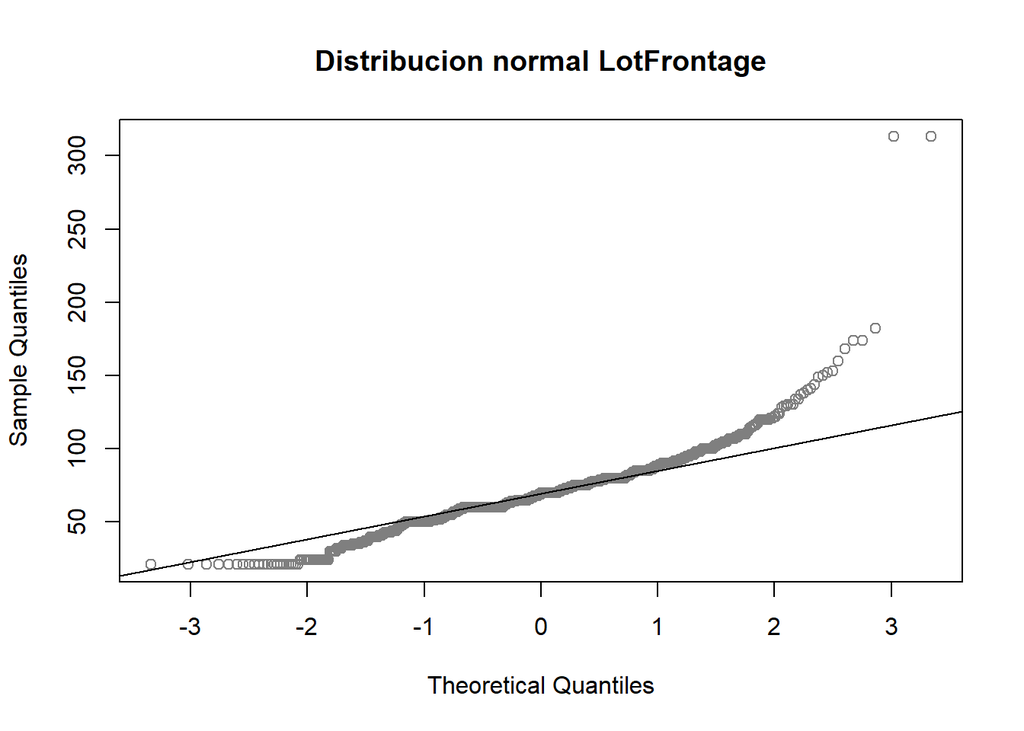

Los datos se aproximan bastante a una distribución normal, sin embargo, tanto al inicio como al final se puede ver cómo estos datos se desvían de la tendencia que debería de seguir.

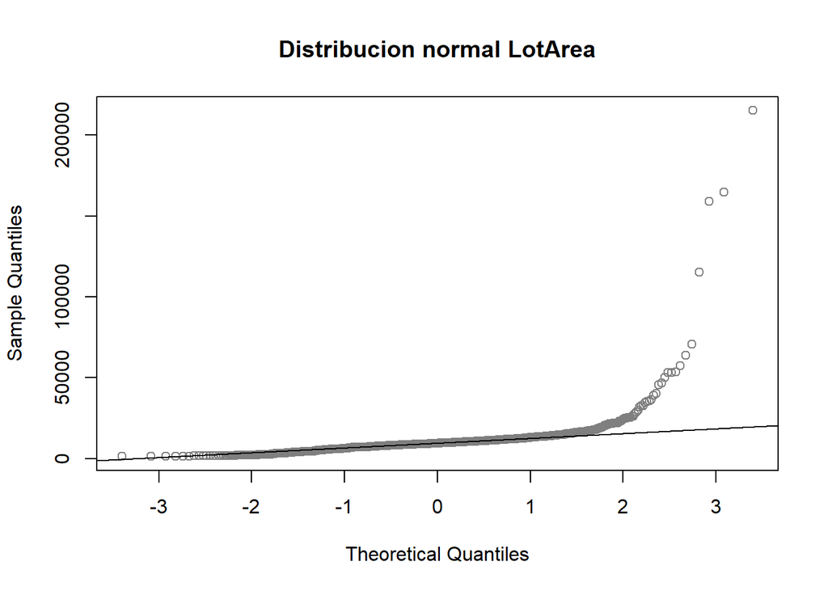

Los datos se aproximan bastante a una distribución normal, pero se puede notar que al final de la gráfica, los datos se desvían, lo que indica que hay un sesgo.

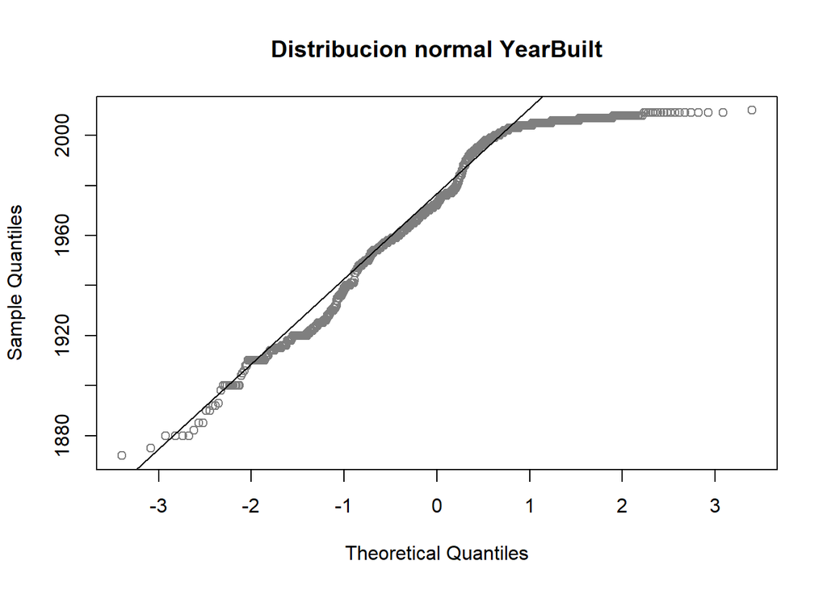

```r
qqnorm(train$YearBuilt, col= "gray50", main = "Distribucion normal YearBuilt")
qqline(train$YearBuilt)
```

Los datos se aproximan bastante a una distribución normal, pero se puede notar que al final de la gráfica, los datos se desvían, lo que indica que hay un sesgo.

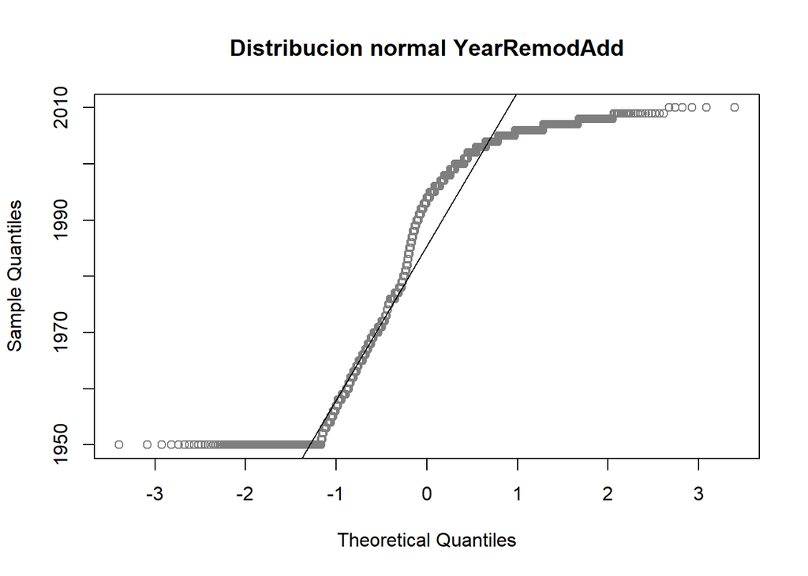

Los datos se aproximan bastante a una distribución normal, sin embargo, tanto al inicio como al final se puede ver cómo estos datos se desvían de la tendencia que debería de seguir.

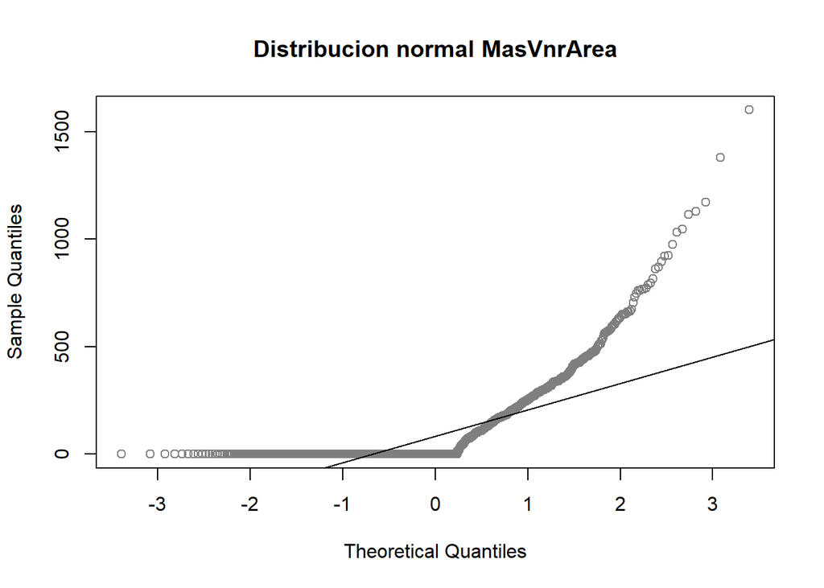

Como se puede observar en la gráfica, los datos no tienen una tendencia normal, pues estos no siguen la línea indicada.

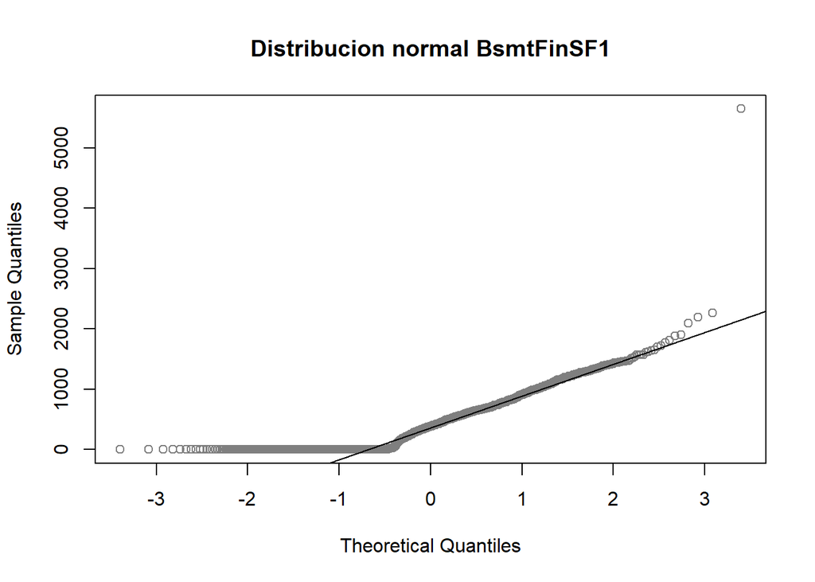

Los datos se aproximan bastante a una distribución normal, pero se puede notar que al inicio de la gráfica, los datos se desvían, lo que indica que hay un sesgo.

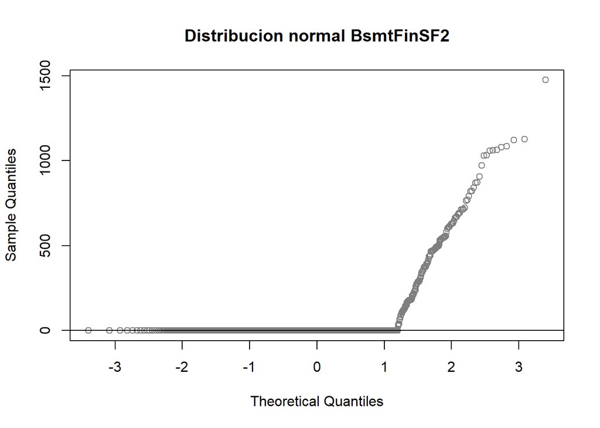

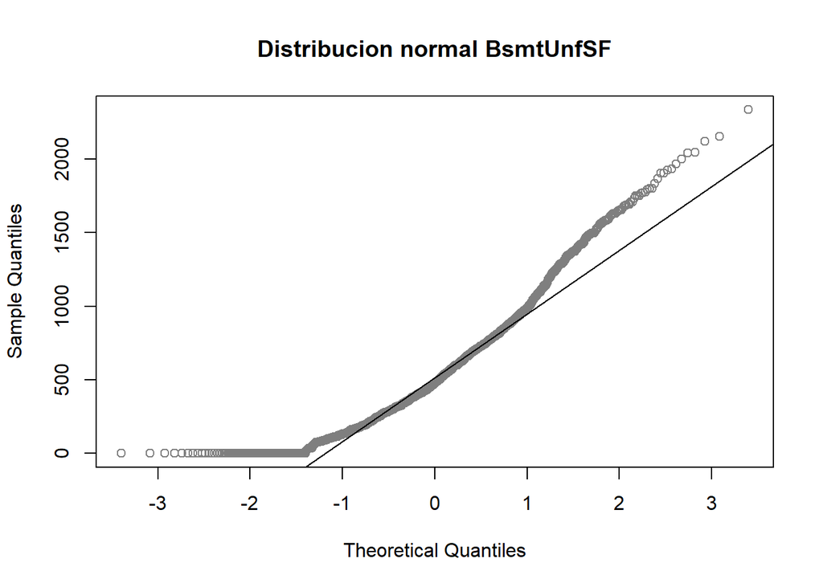

Los datos se aproximan bastante a una distribución normal, sin embargo, tanto al inicio como al final se puede ver cómo estos datos se desvían de la tendencia que debería de seguir.

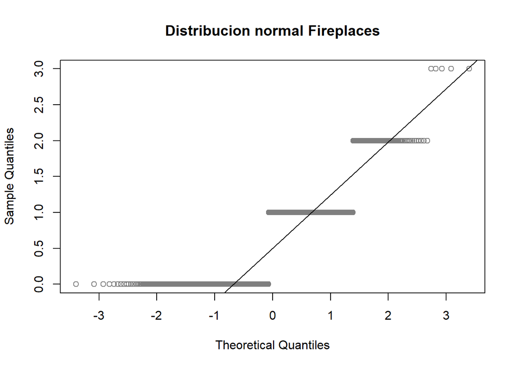

Como se puede observar en la gráfica, los datos no tienen una tendencia normal, aunque estos siguen la línea indicada, pero debido a la cantidad de valores que toman estos datos no se logra apreciar.

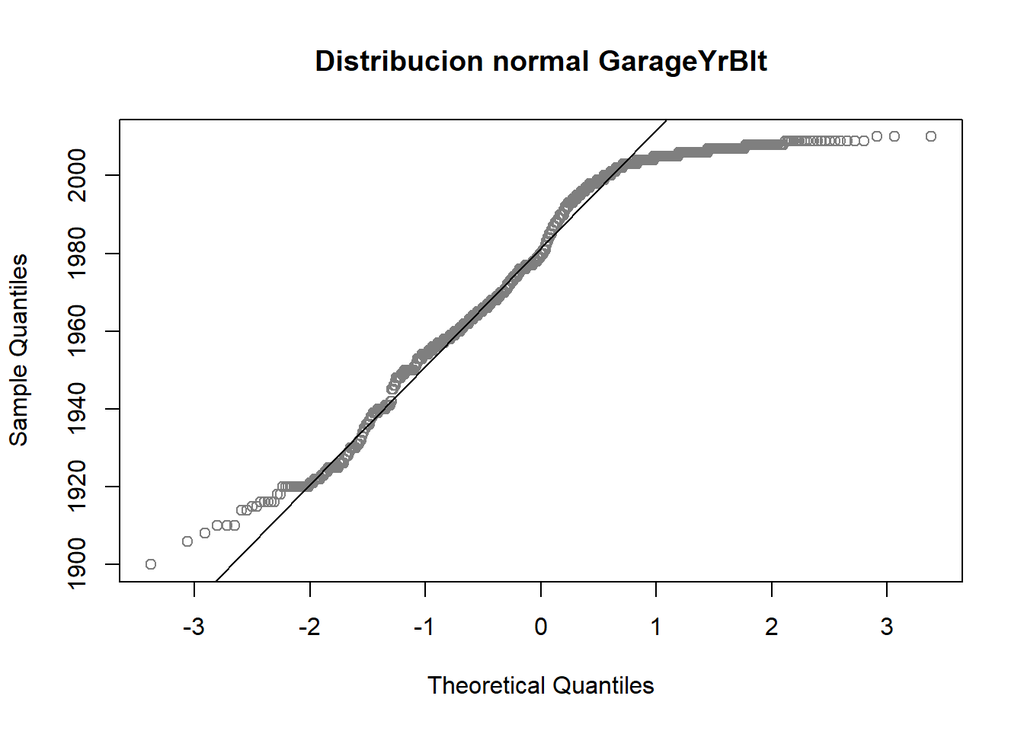

Los datos se aproximan bastante a una distribución normal, pero se puede notar que al final de la gráfica, los datos se desvían, lo que indica que hay un sesgo.

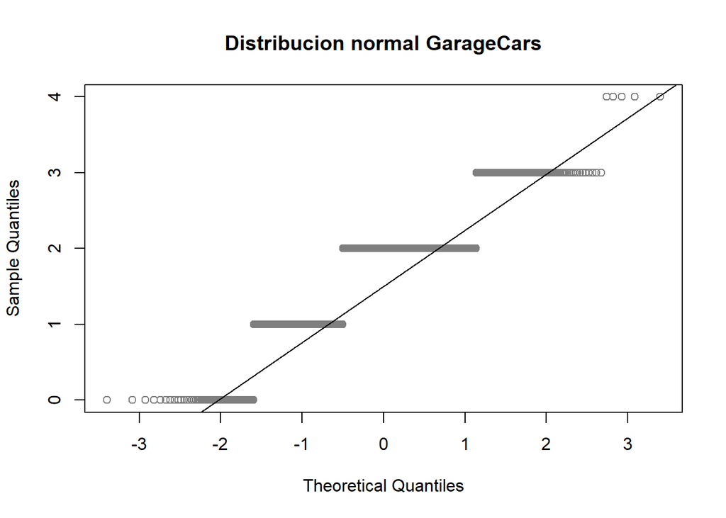

Como se puede observar en la gráfica, los datos no tienen una tendencia normal, aunque estos siguen la línea indicada, pero debido a la cantidad de valores que toman estos datos no se logra apreciar.

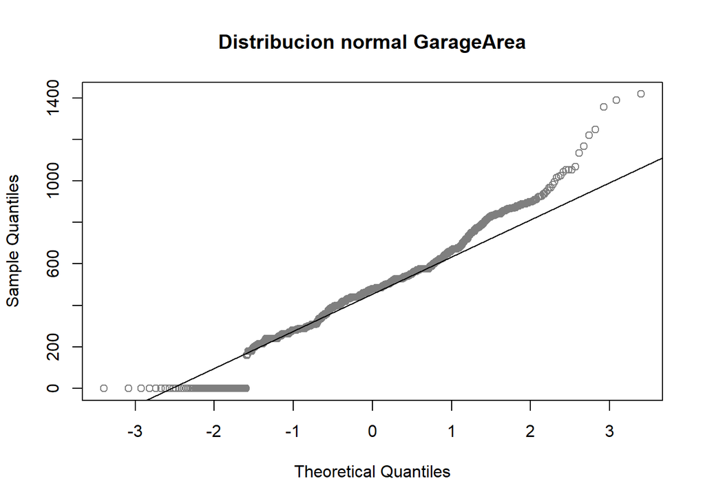

Los datos se aproximan bastante a una distribución normal, sin embargo, tanto al inicio como al final se puede ver cómo estos datos se desvían de la tendencia que debería de seguir.

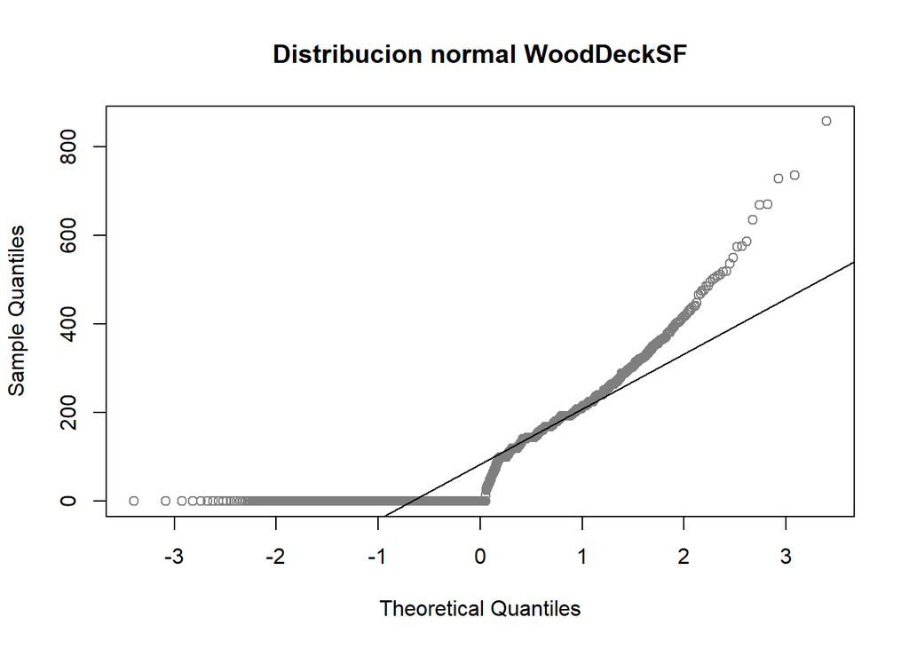

Como se puede observar en la gráfica, los datos no tienen una tendencia normal, pues estos no siguen la línea indicada.

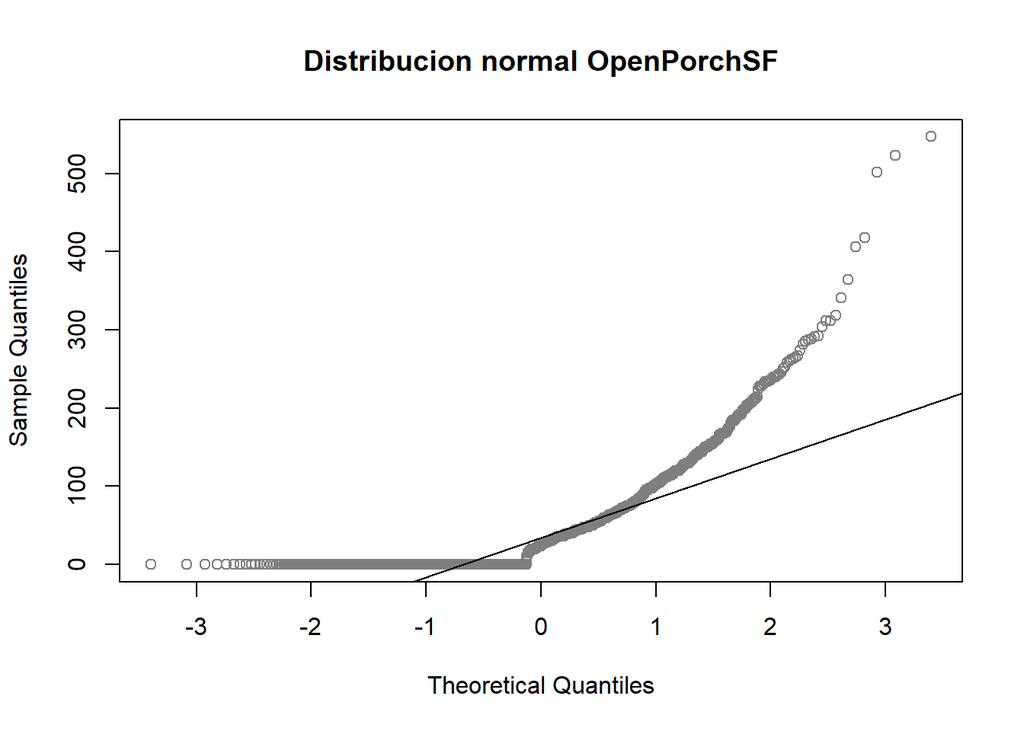

Como se puede observar en la gráfica, los datos no tienen una tendencia normal, pues estos no siguen la línea indicada.

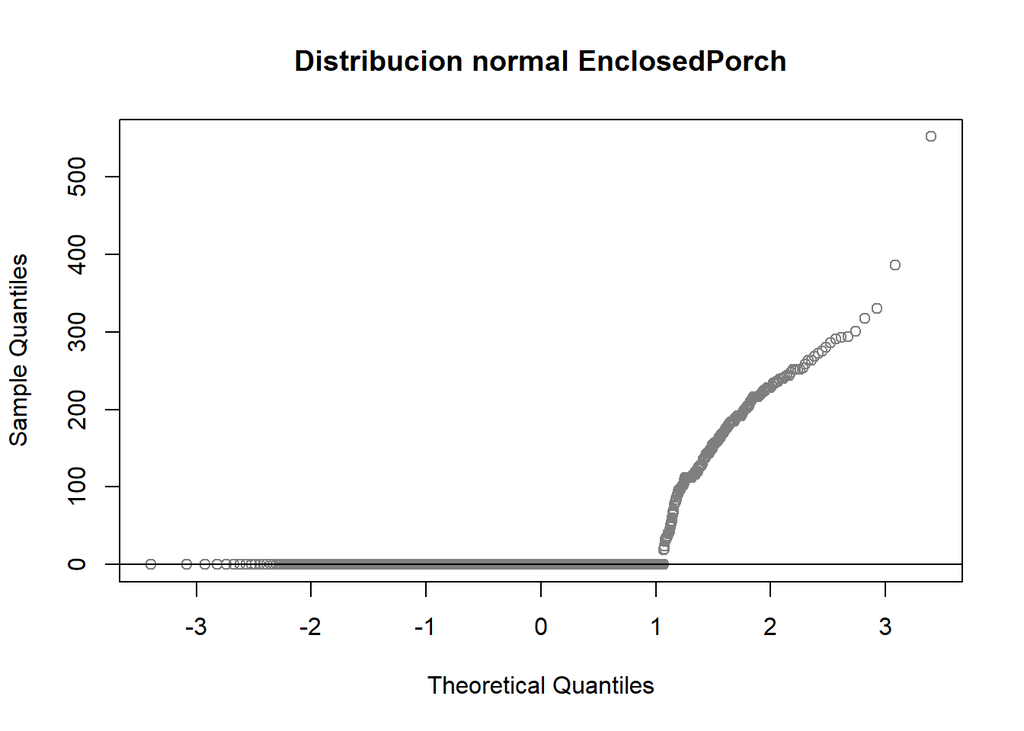

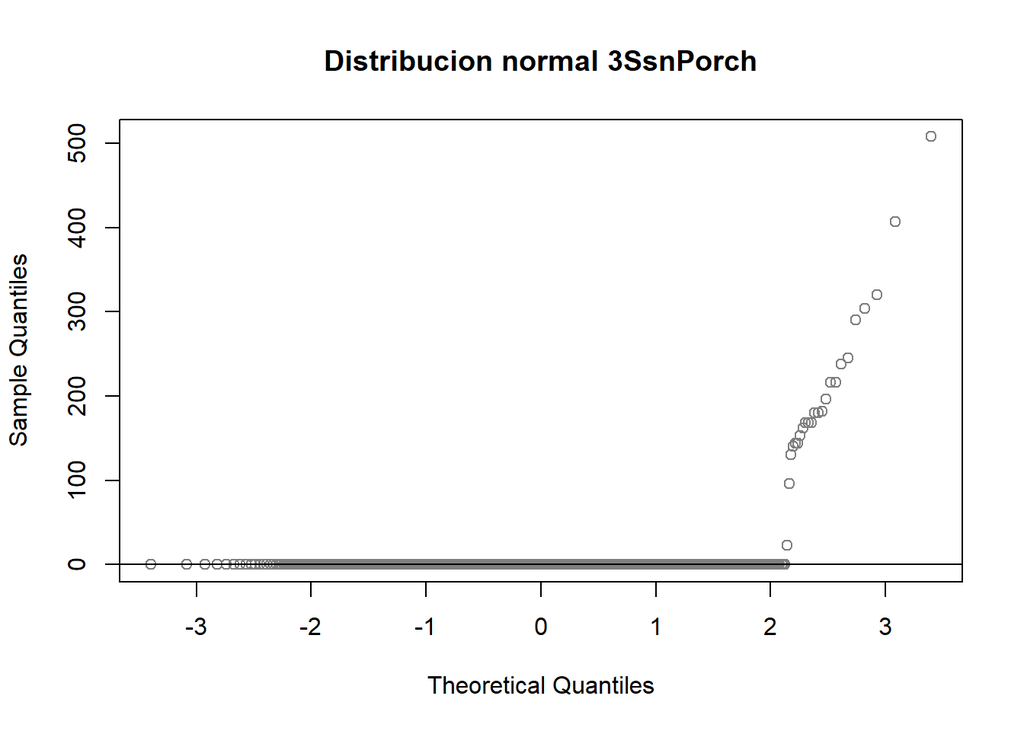

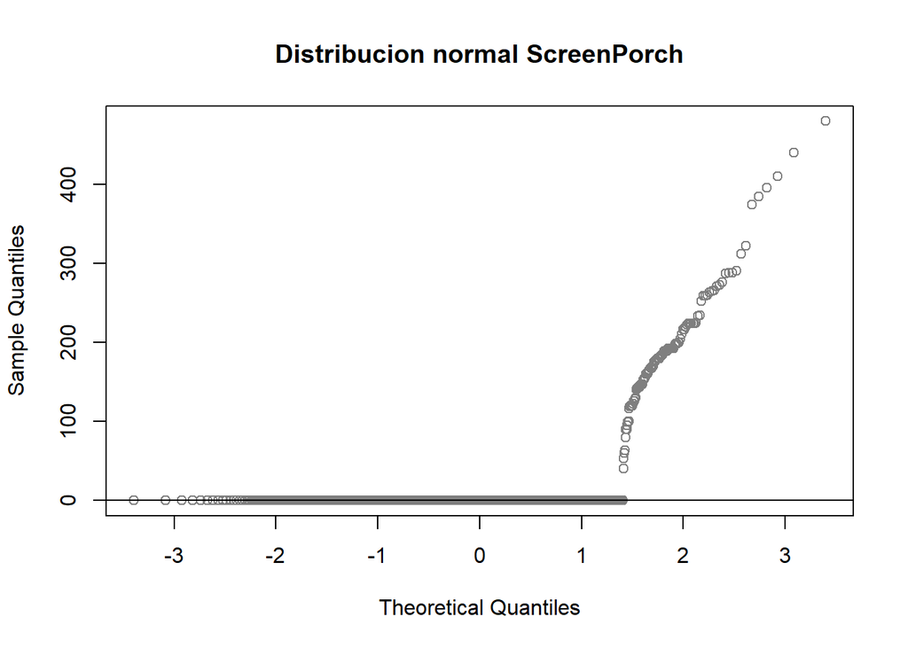

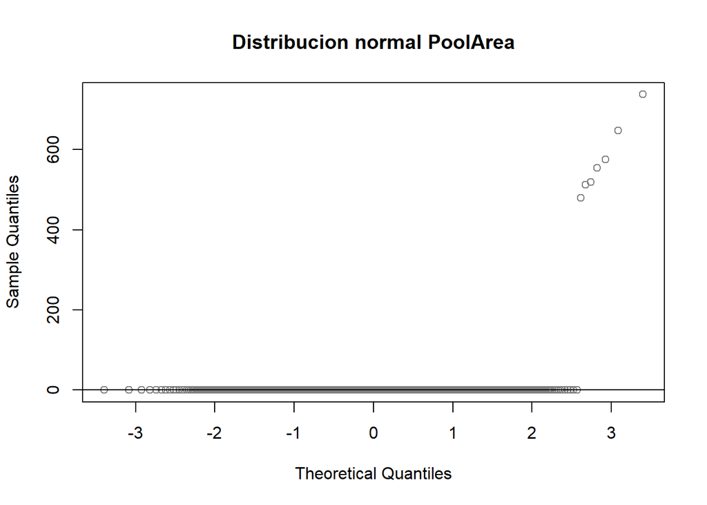

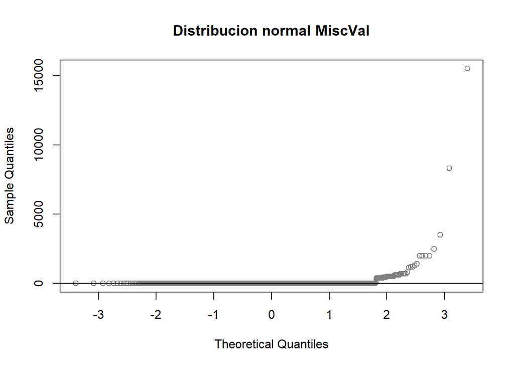

Al igual que el caso anterior, la mayoría de los datos no cuentan con un valor para esta variable, por lo que se sesga la distribución normal.

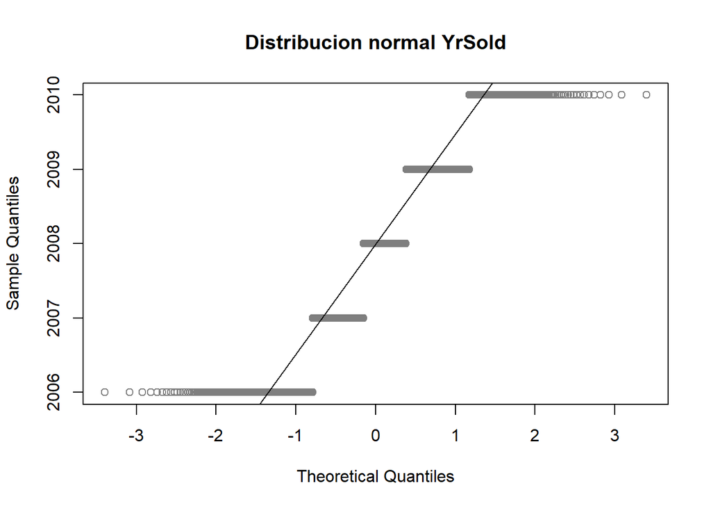

Como se puede observar en la gráfica, los datos no tienen una tendencia normal, aunque estos siguen la línea indicada, pero debido a la cantidad de valores que toman estos datos no se logra apreciar.

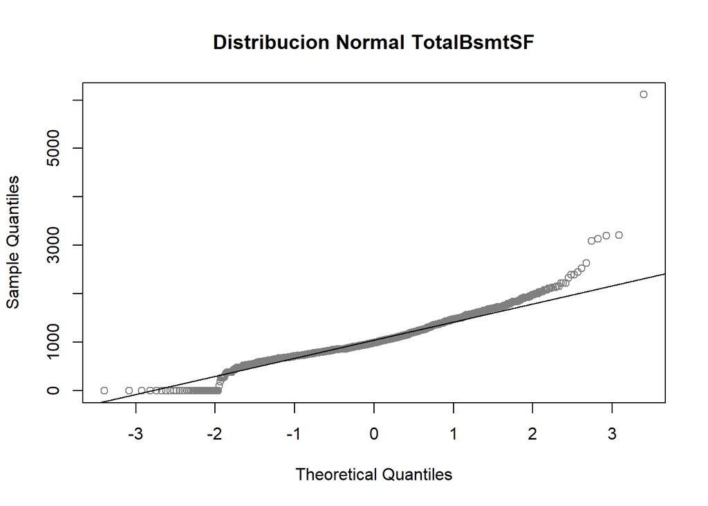

```r
qqnorm(train$TotalBsmtSF, col= "gray50", main = "Distribucion Normal TotalBsmtSF")
qqline(train$TotalBsmtSF)
```

Los datos se aproximan bastante a una distribución normal, sin embargo, tanto al inicio como al final se puede ver cómo estos datos se desvían de la tendencia que debería de seguir.

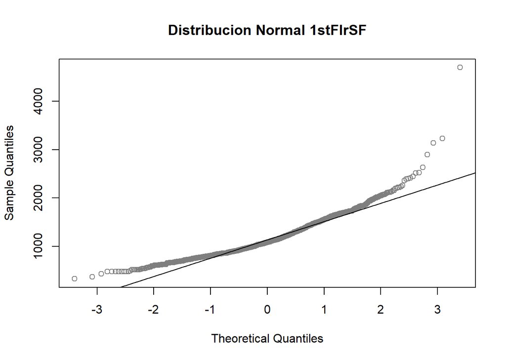

```r
qqnorm(train$X1stFlrSF, col= "gray50", main = "Distribucion Normal 1stFlrSF")
qqline(train$X1stFlrSF)
```

Los datos se aproximan bastante a una distribución normal, sin embargo, tanto al inicio como al final se puede ver cómo estos datos se desvían de la tendencia que debería de seguir.

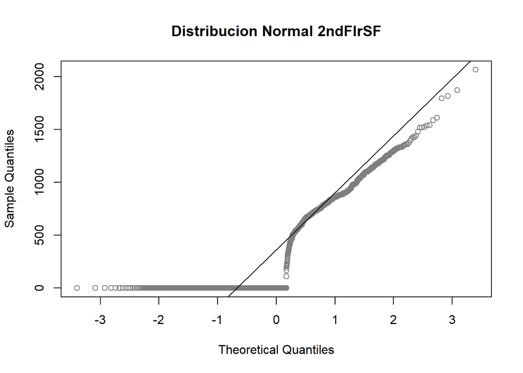

```r
qqnorm(train$X2ndFlrSF, col= "gray50", main = "Distribucion Normal 2ndFlrSF")
qqline(train$X2ndFlrSF)
```

Como se puede observar en la gráfica, los datos no tienen una tendencia normal, pues estos no siguen la línea indicada.

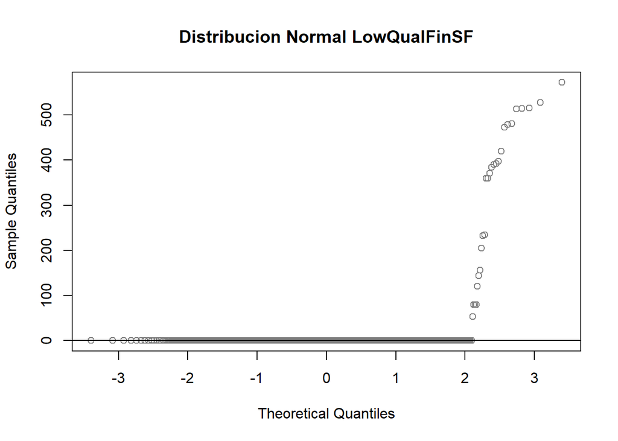

```r
qqnorm(train$LowQualFinSF, col= "gray50", main = "Distribucion Normal LowQualFinSF")
qqline(train$LowQualFinSF)
```

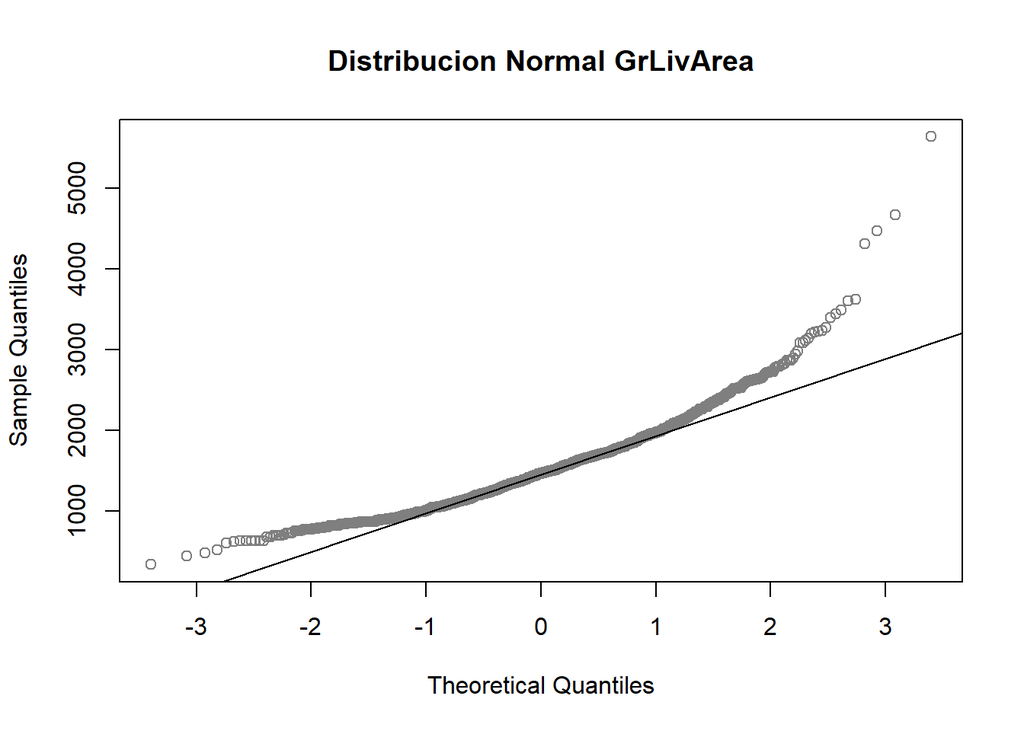

```r
qqnorm(train$GrLivArea, col= "gray50", main = "Distribucion Normal GrLivArea")
qqline(train$GrLivArea)
```

Los datos se aproximan bastante a una distribución normal, sin embargo, tanto al inicio como al final se puede ver cómo estos datos se desvían de la tendencia que debería de seguir.

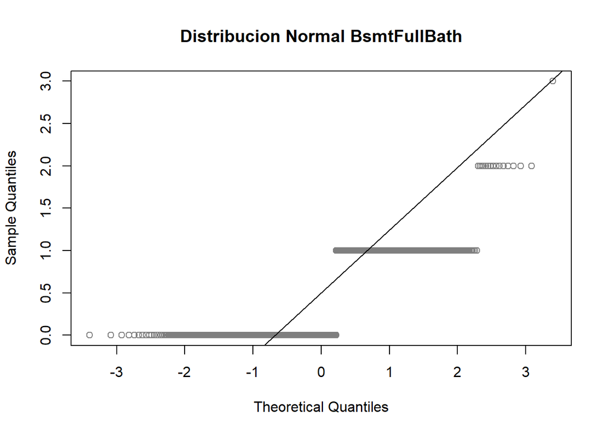

```r
qqnorm(train$BsmtFullBath, col= "gray50", main = "Distribucion Normal BsmtFullBath")
qqline(train$BsmtFullBath)
```

Como se puede observar en la gráfica, los datos no tienen una tendencia normal, aunque estos siguen la línea indicada, pero debido a la cantidad de valores que toman estos datos no se logra apreciar.

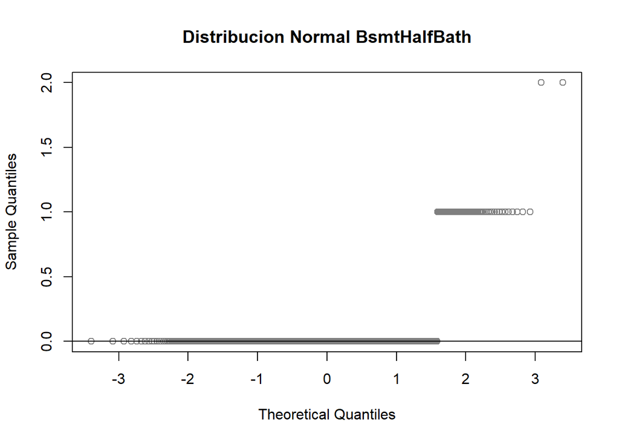

```r
qqnorm(train$BsmtHalfBath, col= "gray50", main = "Distribucion Normal BsmtHalfBath")
qqline(train$BsmtHalfBath)
```

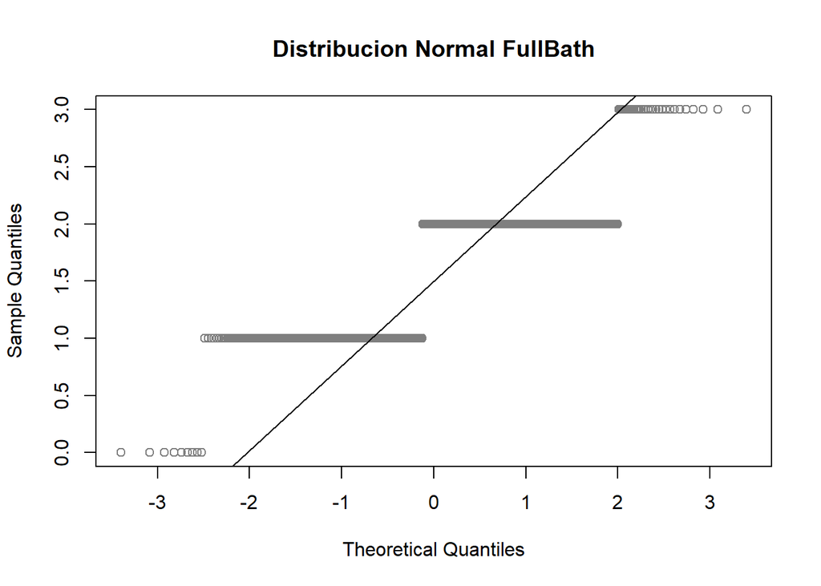

```r
qqnorm(train$FullBath, col= "gray50", main = "Distribucion Normal FullBath")
qqline(train$FullBath)
```

Como se puede observar en la gráfica, los datos no tienen una tendencia normal, aunque estos siguen la línea indicada, pero debido a la cantidad de valores que toman estos datos no se logra apreciar.

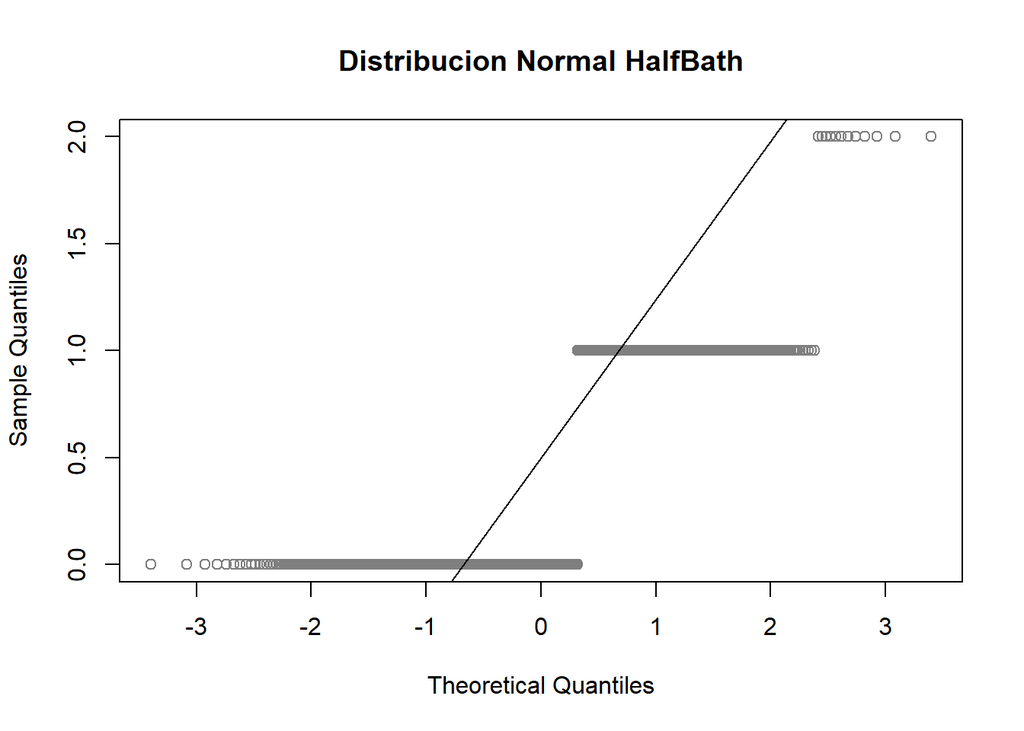

```r
qqnorm(train$HalfBath, col= "gray50", main = "Distribucion Normal HalfBath")
qqline(train$HalfBath)
```

Como se puede observar en la gráfica, los datos no tienen una tendencia normal, aunque estos siguen la línea indicada, pero debido a la cantidad de valores que toman estos datos no se logra apreciar.

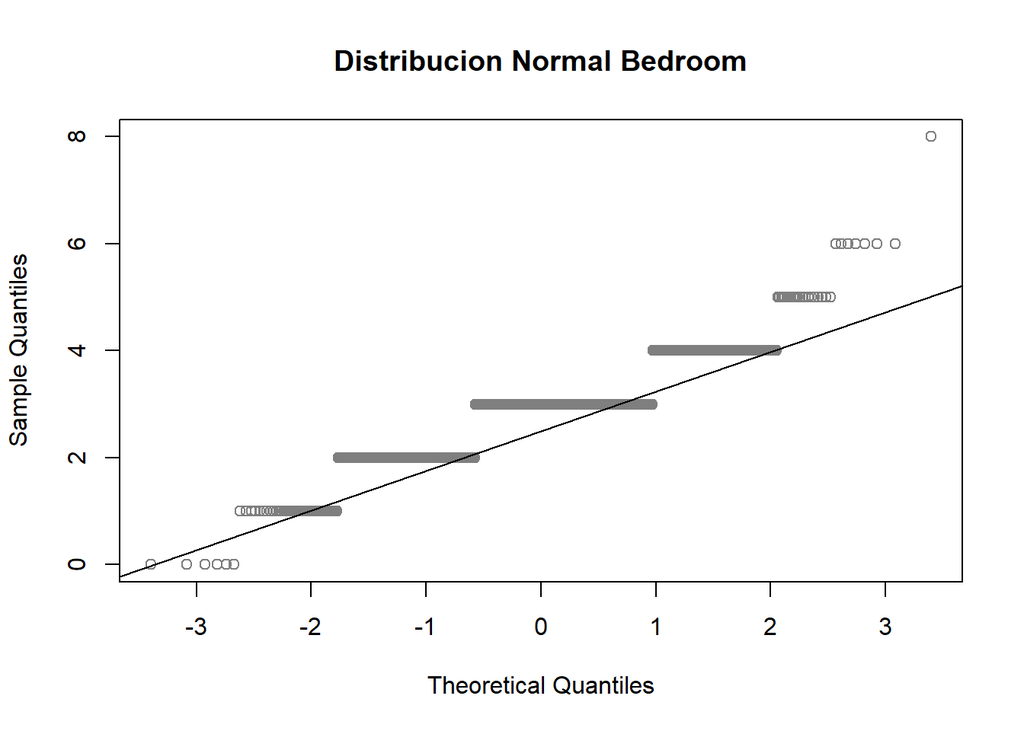

```r
qqnorm(train$Bedroom, col= "gray50", main = "Distribucion Normal Bedroom")
qqline(train$Bedroom)
```

Como se puede observar en la gráfica, los datos no tienen una tendencia normal, aunque estos siguen la línea indicada, pero debido a la cantidad de valores que toman estos datos no se logra apreciar.

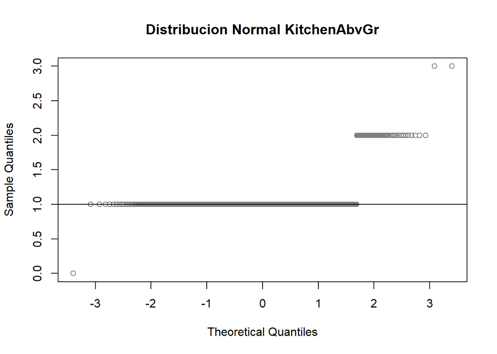

```r
qqnorm(train$KitchenAbvGr, col= "gray50", main = "Distribucion Normal KitchenAbvGr")
qqline(train$KitchenAbvGr)
```

Como se puede observar en la gráfica, los datos no tienen una tendencia normal, aunque estos siguen la línea indicada, pero debido a la cantidad de valores que toman estos datos no se logra apreciar.

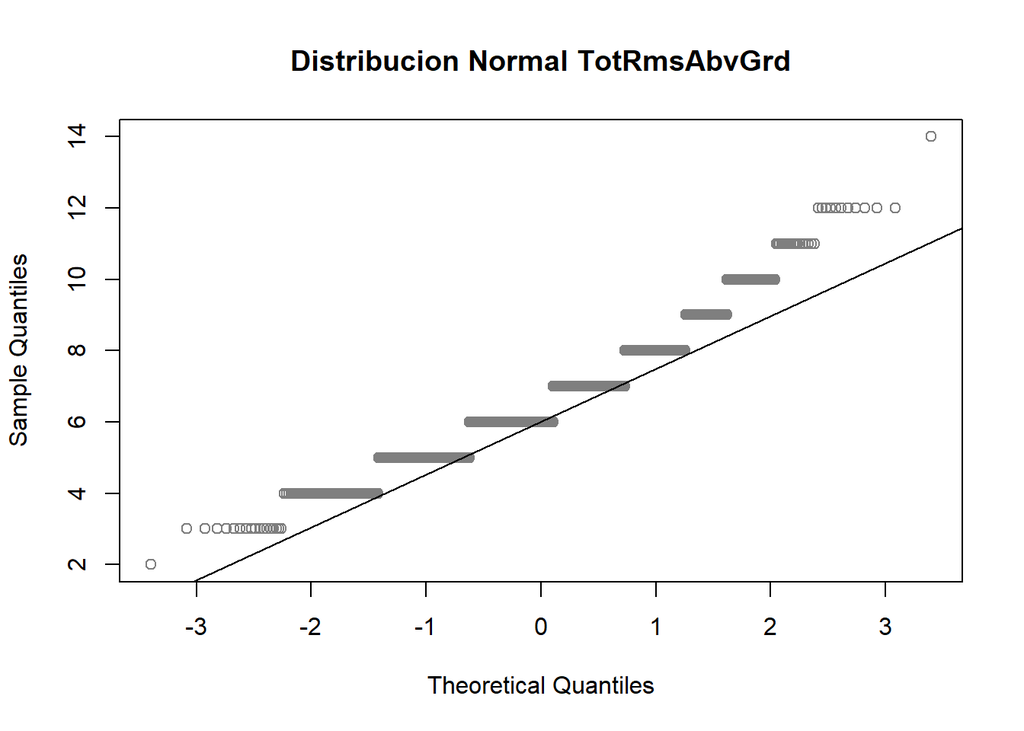

```r
qqnorm(train$TotRmsAbvGrd, col= "gray50", main = "Distribucion Normal TotRmsAbvGrd")
qqline(train$TotRmsAbvGrd)
```

Como se puede observar en la gráfica, los datos no tienen una tendencia normal, aunque estos siguen la línea indicada, pero debido a la cantidad de valores que toman estos datos no se logra apreciar.